# Project 3, Aim 2: Data Processing & Analysis

WB

2026-10-21

# Overview

This document details preliminary/interim analysis from the Project 3, Aim 2 baseline surveys with 4 clinics: Orthopedics, Gastroenterology, Adolescent and Young Adult Medicine and Endocrinology. Results are presented first, then Methods at the end **may end up deepening the methods if necessary**

# Key Findings

- **49 staff completed the baseline survey** across 4 clinics. Orthopedics makes up 61% of the sample.
- **Recognition is the weakest part of implementation climate.** Staff rated their own experience of it at 2.46 on a 1–5 scale, compared with 3.37 for Focus and 3.44 for Support.
- **Staff rate their clinic more favorably than themselves** in all three areas (clinic vs. self: Focus 3.83 vs. 3.37; Support 3.74 vs. 3.44; Recognition 2.89 vs. 2.46). See Self vs. Clinic.
- **Team psychological safety averages 5.31** on a 1–7 scale, and collaboration on care decisions averages 4.35.
- **Clinic groups are small** (Endocrinology: n = 4), so differences between clinics should be read as descriptive.

# Sample

```r
# Respondents by clinic, with a small bar showing each clinic's share
clinic_table <- df %>%
  mutate(Clinic = as.character(Clinic),
         Clinic = ifelse(is.na(Clinic), "Not reported", Clinic)) %>%
  count(Clinic) %>%
  mutate(pct = n / sum(n)) %>%
  arrange(desc(n))

bar <- function(p) sprintf(
  "<div style='background:#2780e3;opacity:.8;height:14px;width:%.0fpx;border-radius:3px'></div>",
  p * 260)

clinic_display <- clinic_table %>%
  transmute(Clinic, n, `%` = sprintf("%.1f%%", 100 * pct), Share = bar(pct)) %>%
  bind_rows(tibble(Clinic = "Total", n = sum(clinic_table$n), `%` = "100.0%", Share = ""))

clinic_display %>%
  kable(format = "html", escape = FALSE, align = c("l", "r", "r", "l"),
        caption = "Respondents by clinic") %>%
  kable_styling(bootstrap_options = c("hover", "condensed"),
                full_width = FALSE, position = "left") %>%
  column_spec(4, width = "280px") %>%
  row_spec(nrow(clinic_display), bold = TRUE,
           extra_css = "border-top: 2px solid #999;")
```

Respondents by clinic

| Clinic | n | % | Share |
| --- | --- | --- | --- |
| Orthopedics | 30 | 61.2% |  |
| Gastroenterology | 8 | 16.3% |  |
| Adolescent Young Adult Medicine | 7 | 14.3% |  |
| Endocrinology | 4 | 8.2% |  |
| Total | 49 | 100.0% |  |

```r
# Readable row names for Table 1
table1::label(df$Clinic)              <- "Clinic"
table1::label(df$position_group)      <- "Position"
table1::label(df$Experience)          <- "Experience (years)"
table1::label(df$IC_Total)            <- "Implementation Climate (1–5)"
table1::label(df$EPSC_Total)          <- "Team Psychological Safety (1–7)"
table1::label(df$CSACD_Collaboration) <- "Collaboration on Care Decisions (1–7)"

table1::table1(~ Gender + Race + Ethnicity + position_group + Experience +
                 IC_Total + EPSC_Total + CSACD_Collaboration | Clinic,
               data = df,
               overall = "All clinics",
               topclass = "Rtable1-zebra Rtable1-shade",
               render.continuous = c(. = "Mean (SD)", . = "Median [Min, Max]"),
               caption = "Participant characteristics by clinic",
               footnote = "Scores are means of each scale's items. Missing = no response to that question.")
```

Participant characteristics by clinic

|  | Adolescent Young Adult Medicine (N=7) | Endocrinology (N=4) | Gastroenterology (N=8) | Orthopedics (N=30) | All clinics (N=49) |
| --- | --- | --- | --- | --- | --- |
| Gender |  |  |  |  |  |
| Woman | 7 (100%) | 4 (100%) | 6 (75.0%) | 22 (73.3%) | 39 (79.6%) |
| Man | 0 (0%) | 0 (0%) | 2 (25.0%) | 7 (23.3%) | 9 (18.4%) |
| Prefer not to answer | 0 (0%) | 0 (0%) | 0 (0%) | 1 (3.3%) | 1 (2.0%) |
| Race |  |  |  |  |  |
| White | 3 (42.9%) | 2 (50.0%) | 4 (50.0%) | 18 (60.0%) | 27 (55.1%) |
| Black or African American | 0 (0%) | 0 (0%) | 0 (0%) | 1 (3.3%) | 1 (2.0%) |
| American Indian or Native Alaskan | 0 (0%) | 0 (0%) | 0 (0%) | 0 (0%) | 0 (0%) |
| Asian | 0 (0%) | 2 (50.0%) | 2 (25.0%) | 2 (6.7%) | 6 (12.2%) |
| Native Hawaiian or Pacific Islander | 0 (0%) | 0 (0%) | 0 (0%) | 0 (0%) | 0 (0%) |
| More than one | 0 (0%) | 0 (0%) | 0 (0%) | 3 (10.0%) | 3 (6.1%) |
| Other | 3 (42.9%) | 0 (0%) | 2 (25.0%) | 4 (13.3%) | 9 (18.4%) |
| Prefer not to answer | 1 (14.3%) | 0 (0%) | 0 (0%) | 2 (6.7%) | 3 (6.1%) |
| Ethnicity |  |  |  |  |  |
| Hispanic | 3 (42.9%) | 0 (0%) | 3 (37.5%) | 12 (40.0%) | 18 (36.7%) |
| Non-Hispanic | 3 (42.9%) | 4 (100%) | 5 (62.5%) | 17 (56.7%) | 29 (59.2%) |
| Prefer not to answer | 1 (14.3%) | 0 (0%) | 0 (0%) | 1 (3.3%) | 2 (4.1%) |
| Position |  |  |  |  |  |
| Allied Health / Technician | 0 (0%) | 0 (0%) | 0 (0%) | 6 (20.0%) | 6 (12.2%) |
| Medical Assistant / Patient Access | 2 (28.6%) | 0 (0%) | 1 (12.5%) | 13 (43.3%) | 16 (32.7%) |
| Other Staff | 1 (14.3%) | 2 (50.0%) | 3 (37.5%) | 1 (3.3%) | 7 (14.3%) |
| Physician | 2 (28.6%) | 2 (50.0%) | 2 (25.0%) | 1 (3.3%) | 7 (14.3%) |
| Physician Assistant | 0 (0%) | 0 (0%) | 0 (0%) | 6 (20.0%) | 6 (12.2%) |
| RN / Nurse Practitioner | 2 (28.6%) | 0 (0%) | 2 (25.0%) | 3 (10.0%) | 7 (14.3%) |
| Experience (years) |  |  |  |  |  |
| Mean (SD) | 6.00 (4.24) | NA | 3.00 (2.08) | 6.80 (7.72) | 5.72 (6.48) |
| Median [Min, Max] | 4.50 [3.00, 12.0] | 2.00 [2.00, 2.00] | 3.00 [1.00, 7.00] | 3.50 [0, 27.0] | 3.00 [0, 27.0] |
| Missing | 3 (42.9%) | 3 (75.0%) | 1 (12.5%) | 10 (33.3%) | 17 (34.7%) |
| Implementation Climate (1–5) |  |  |  |  |  |
| Mean (SD) | 3.52 (0.507) | 3.44 (0.815) | 3.39 (0.784) | 3.18 (0.717) | 3.29 (0.701) |
| Median [Min, Max] | 3.42 [2.67, 4.25] | 3.25 [2.67, 4.58] | 3.17 [2.58, 5.00] | 3.04 [2.00, 4.67] | 3.33 [2.00, 5.00] |
| Team Psychological Safety (1–7) |  |  |  |  |  |
| Mean (SD) | 4.96 (0.887) | 5.61 (0.844) | 5.73 (1.06) | 5.25 (0.903) | 5.31 (0.921) |
| Median [Min, Max] | 4.86 [3.57, 6.00] | 5.50 [4.71, 6.71] | 6.00 [4.43, 7.00] | 5.29 [3.83, 6.86] | 5.29 [3.57, 7.00] |
| Missing | 0 (0%) | 0 (0%) | 1 (12.5%) | 0 (0%) | 1 (2.0%) |
| Collaboration on Care Decisions (1–7) |  |  |  |  |  |
| Mean (SD) | 3.90 (1.33) | 5.42 (0.957) | 4.89 (1.60) | 4.20 (1.48) | 4.35 (1.46) |
| Median [Min, Max] | 4.00 [2.00, 6.00] | 5.83 [4.00, 6.00] | 5.33 [2.67, 7.00] | 4.00 [1.00, 7.00] | 4.00 [1.00, 7.00] |
| Missing | 0 (0%) | 0 (0%) | 2 (25.0%) | 2 (6.7%) | 4 (8.2%) |

Scores are means of each scale's items. Missing = no response to that question.

# Self vs. Clinic

Each Implementation Climate area is asked twice: about the respondent’s own experience (“self”) and about their clinic as a whole (“clinic”).

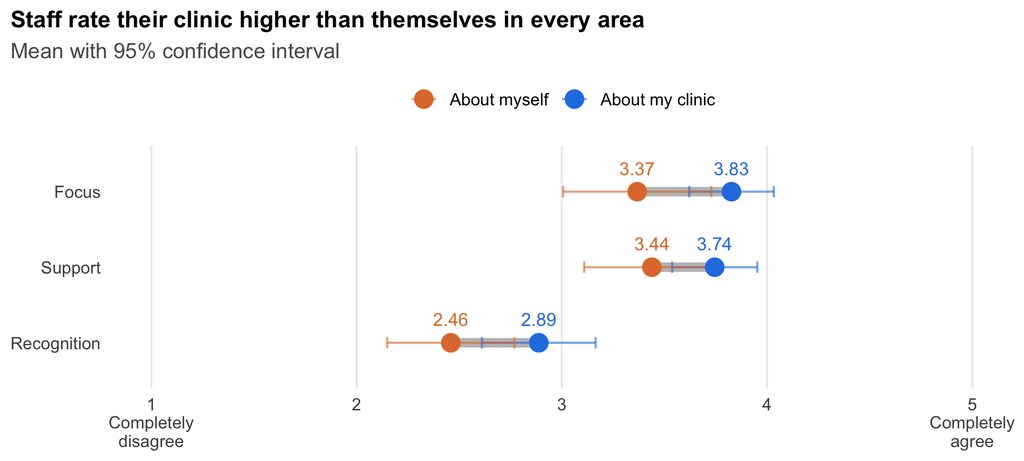

```r
ci_long <- df %>%
  select(starts_with("IC_") & (ends_with("_Self") | ends_with("_Clinic"))) %>%
  pivot_longer(everything(), names_to = c("Domain", "Rater"),
               names_pattern = "IC_(.*)_(Self|Clinic)") %>%
  filter(!is.na(value)) %>%
  group_by(Domain, Rater) %>%
  summarise(n = n(), mean = mean(value), se = sd(value) / sqrt(n),
            lo = mean - qt(0.975, n - 1) * se,
            hi = mean + qt(0.975, n - 1) * se, .groups = "drop") %>%
  mutate(Domain = factor(Domain, levels = rev(domains)),
         Rater  = factor(Rater, levels = c("Self", "Clinic")))

seg <- ci_long %>% select(Domain, Rater, mean) %>%
  pivot_wider(names_from = Rater, values_from = mean)

ggplot(ci_long, aes(x = mean, y = Domain, color = Rater)) +
  geom_segment(data = seg, aes(x = Self, xend = Clinic, y = Domain, yend = Domain),
               inherit.aes = FALSE, color = "grey75", linewidth = 2.5) +
  geom_errorbar(aes(xmin = lo, xmax = hi), width = 0.15, linewidth = 0.6, alpha = 0.6,
                orientation = "y") +
  geom_point(size = 4.5) +
  geom_text(aes(label = f2(mean)), vjust = -1.3, size = 3.6, show.legend = FALSE) +
  scale_color_manual(values = c(Self = col_self, Clinic = col_clinic),
                     labels = c(Self = "About myself", Clinic = "About my clinic"), name = NULL) +
  scale_x_continuous(limits = c(1, 5), breaks = 1:5,
                     labels = c("1\nCompletely\ndisagree", "2", "3", "4", "5\nCompletely\nagree")) +
  labs(title = if (all_higher) "Staff rate their clinic higher than themselves in every area"
               else "Self and clinic ratings of implementation climate",
       subtitle = "Mean with 95% confidence interval",
       x = NULL, y = NULL) +
  theme_report()
```

```r
paired_tests <- map_dfr(domains, function(d) {
  s <- df[[paste0("IC_", d, "_Self")]]
  cl <- df[[paste0("IC_", d, "_Clinic")]]
  ok <- !is.na(s) & !is.na(cl)
  w <- suppressWarnings(wilcox.test(cl[ok], s[ok], paired = TRUE, exact = FALSE))
  tibble(Area = d, n = sum(ok),
         `Self mean` = mean(s[ok]), `Clinic mean` = mean(cl[ok]),
         `Difference (clinic − self)` = mean(cl[ok] - s[ok]),
         `p (Wilcoxon signed-rank)` = w$p.value)
}) %>%
  mutate(`p (Holm-adjusted)` = p.adjust(`p (Wilcoxon signed-rank)`, method = "holm"),
         across(c(`p (Wilcoxon signed-rank)`, `p (Holm-adjusted)`),
                ~ ifelse(.x < 0.001, "< .001", formatC(.x, format = "f", digits = 3))))

pretty_table(paired_tests, caption = "Paired comparison of self vs. clinic ratings")
```

Paired comparison of self vs. clinic ratings

| Area | n | Self mean | Clinic mean | Difference (clinic − self) | p (Wilcoxon signed-rank) | p (Holm-adjusted) |
| --- | --- | --- | --- | --- | --- | --- |
| Focus | 49 | 3.37 | 3.83 | 0.46 | 0.009 | 0.018 |
| Support | 49 | 3.44 | 3.74 | 0.31 | 0.039 | 0.039 |
| Recognition | 49 | 2.46 | 2.89 | 0.43 | < .001 | 0.002 |

# Item-Level Responses

How respondents answered each of the 12 Implementation Climate items.

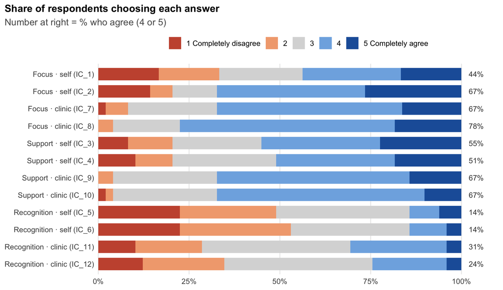

```r
ic_item_info <- tibble(
  item   = paste0("IC_", 1:12),
  Domain = rep(c("Focus", "Focus", "Support", "Support", "Recognition", "Recognition"), 2),
  Rater  = rep(c("Self", "Clinic"), each = 6)
) %>%
  mutate(label = paste0(Domain, " · ", tolower(Rater), " (", item, ")"))

ic_items_long <- df %>%
  select(all_of(ic_item_info$item)) %>%
  pivot_longer(everything(), names_to = "item", values_to = "response") %>%
  filter(!is.na(response)) %>%
  count(item, response) %>%
  group_by(item) %>% mutate(share = n / sum(n)) %>% ungroup() %>%
  left_join(ic_item_info, by = "item") %>%
  mutate(response = factor(response, levels = 5:1),
         label = factor(label, levels = rev(ic_item_info$label[order(
           match(ic_item_info$Domain, domains), ic_item_info$Rater == "Clinic")])))

agree_share <- ic_items_long %>%
  filter(response %in% c("4", "5")) %>%
  group_by(label) %>% summarise(agree = sum(share), .groups = "drop")

ggplot(ic_items_long, aes(x = share, y = label, fill = response)) +
  geom_col(width = 0.72) +
  geom_text(data = agree_share, aes(x = 1.02, y = label, label = pct(agree)),
            inherit.aes = FALSE, hjust = 0, size = 3.4, color = "grey25") +
  scale_fill_manual(values = c("5" = "#1F5FA8", "4" = "#7FB1E3", "3" = "#D9D9D9",
                               "2" = "#F2A97E", "1" = "#C8553D"),
                    breaks = as.character(1:5),
                    labels = c("1 Completely disagree", "2", "3", "4", "5 Completely agree"),
                    name = NULL) +
  scale_x_continuous(labels = function(x) paste0(round(x * 100), "%"),
                     breaks = seq(0, 1, 0.25), expand = expansion(mult = c(0, 0.08))) +
  labs(title = "Share of respondents choosing each answer",
       subtitle = "Number at right = % who agree (4 or 5)", x = NULL, y = NULL) +
  coord_cartesian(clip = "off") +
  theme_report() +
  guides(fill = guide_legend(nrow = 1, reverse = FALSE))
```

# Clinic Comparisons

## Distributions

Each dot is one respondent; boxes show the median and middle 50%.

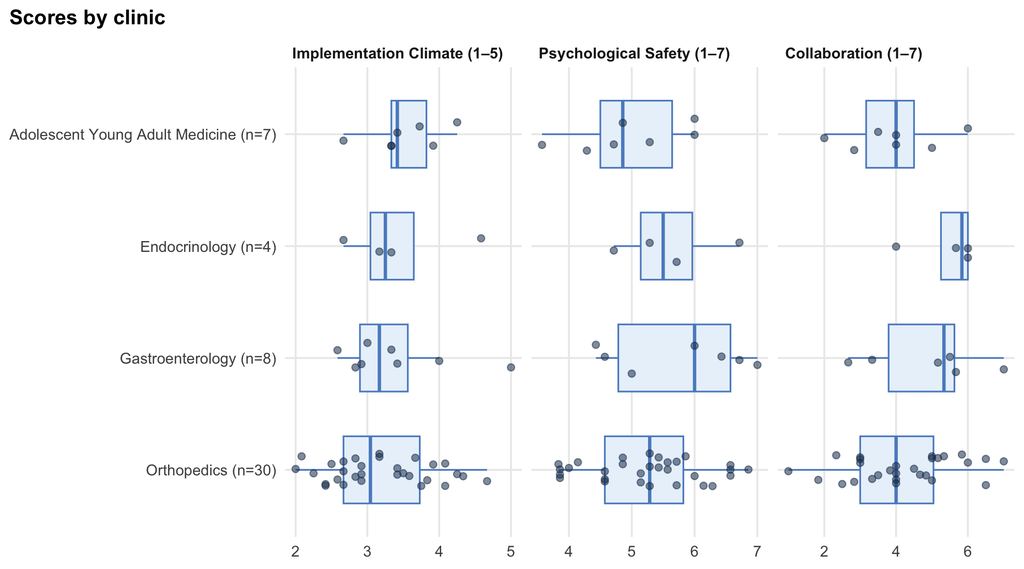

```r
main_scores <- c("IC_Total", "EPSC_Total", "CSACD_Collaboration")
facet_titles <- c(IC_Total = "Implementation Climate (1–5)",
                  EPSC_Total = "Psychological Safety (1–7)",
                  CSACD_Collaboration = "Collaboration (1–7)")

box_df <- df %>%
  filter(!is.na(Clinic)) %>%
  add_count(Clinic, name = "n_clinic") %>%
  mutate(Clinic_lab = paste0(Clinic, " (n=", n_clinic, ")")) %>%
  select(Clinic_lab, all_of(main_scores)) %>%
  pivot_longer(-Clinic_lab, names_to = "score", values_to = "value") %>%
  filter(!is.na(value)) %>%
  mutate(score = factor(facet_titles[score], levels = facet_titles[main_scores]))

set.seed(1)
ggplot(box_df, aes(x = value, y = fct_rev(Clinic_lab))) +
  geom_boxplot(outlier.shape = NA, fill = "#EAF2FB", color = "#5B8DC9", width = 0.6) +
  geom_jitter(height = 0.15, width = 0, size = 1.8, alpha = 0.55, color = "#1F3B5C") +
  facet_wrap(~ score, scales = "free_x", ncol = 3) +
  labs(title = "Scores by clinic", x = NULL, y = NULL) +
  theme_report() +
  theme(panel.grid.major.y = element_line(color = "grey92"))
```

## Table and tests

Mean (SD) for every score. Shading runs from lighter (lower) to darker (higher) within each row. Kruskal-Wallis tests whether scores differ across clinics; ε² is the effect size (roughly .01 small, .08 medium, .26 large).

```r
clinic_levels <- levels(droplevels(df$Clinic[!is.na(df$Clinic)]))

kw <- map_dfr(score_vars, function(v) {
  d <- df %>% filter(!is.na(Clinic), !is.na(.data[[v]]))
  t <- kruskal.test(d[[v]] ~ droplevels(d$Clinic))
  tibble(score = v, H = unname(t$statistic), p = t$p.value,
         eps2 = unname(t$statistic) / (nrow(d) - 1))
}) %>%
  mutate(p_holm = p.adjust(p, method = "holm"))

stats_long <- df %>%
  filter(!is.na(Clinic)) %>%
  select(Clinic, all_of(score_vars)) %>%
  pivot_longer(-Clinic, names_to = "score") %>%
  group_by(score, Clinic) %>%
  summarise(m = mean(value, na.rm = TRUE), s = sd(value, na.rm = TRUE), .groups = "drop") %>%
  group_by(score) %>%
  mutate(shade = (m - min(m)) / max(max(m) - min(m), 1e-9)) %>%
  ungroup()

shade_col <- colorRampPalette(c("#F4F8FB", "#9EC5EE"))(101)

cells <- stats_long %>%
  mutate(cell = cell_spec(paste0(f2(m), " (", f2(s), ")"),
                          background = shade_col[round(shade * 100) + 1],
                          color = "#1b1b1b")) %>%
  select(score, Clinic, cell) %>%
  pivot_wider(names_from = Clinic, values_from = cell)

fmt_p <- function(p) ifelse(p < 0.001, "< .001", formatC(p, format = "f", digits = 3))

clinic_comparison <- cells %>%
  left_join(kw, by = "score") %>%
  mutate(score = factor(score, levels = score_vars)) %>%
  arrange(score) %>%
  transmute(Score = score_labels[as.character(score)],
            !!!syms(clinic_levels),
            `ε²` = f2(eps2), p = fmt_p(p), `p (Holm)` = fmt_p(p_holm))

clinic_n_lab <- clinic_n %>% mutate(lab = paste0(Clinic, "<br><span class='note-small'>n = ", n, "</span>"))
names(clinic_comparison)[match(clinic_levels, names(clinic_comparison))] <-
  clinic_n_lab$lab[match(clinic_levels, clinic_n_lab$Clinic)]

clinic_comparison %>%
  kable(format = "html", escape = FALSE, align = c("l", rep("c", length(clinic_levels)), "r", "r", "r"),
        caption = "Mean (SD) by clinic, with Kruskal-Wallis tests") %>%
  kable_styling(bootstrap_options = c("hover", "condensed"), full_width = TRUE) %>%
  column_spec(1, bold = TRUE) %>%
  pack_rows("Implementation Climate (1–5)", 1, 7) %>%
  pack_rows("Psychological Safety (1–7)", 8, 8) %>%
  pack_rows("Care Decisions (CSACD)", 9, 11) %>%
  scroll_box(width = "100%")
```

Mean (SD) by clinic, with Kruskal-Wallis tests

| Score | Adolescent Young Adult Medicine n = 7 | Endocrinology n = 4 | Gastroenterology n = 8 | Orthopedics n = 30 | ε² | p | p (Holm) |
| --- | --- | --- | --- | --- | --- | --- | --- |
| **Implementation Climate (1–5)** |  |  |  |  |  |  |  |
| Implementation Climate (total) | 3.52 (0.51) | 3.44 (0.81) | 3.39 (0.78) | 3.18 (0.72) | 0.04 | 0.631 | 1.000 |
| IC: Focus (self) | 4.07 (0.84) | 2.88 (1.55) | 3.50 (1.20) | 3.23 (1.30) | 0.07 | 0.369 | 1.000 |
| IC: Focus (clinic) | 4.07 (0.73) | 4.12 (0.63) | 3.81 (0.65) | 3.73 (0.75) | 0.03 | 0.725 | 1.000 |
| IC: Support (self) | 3.71 (0.76) | 3.75 (1.26) | 3.31 (1.07) | 3.37 (1.26) | 0.02 | 0.832 | 1.000 |
| IC: Support (clinic) | 4.07 (0.61) | 3.75 (0.50) | 3.38 (1.03) | 3.77 (0.67) | 0.07 | 0.354 | 1.000 |
| IC: Recognition (self) | 2.57 (0.84) | 3.00 (1.08) | 3.06 (1.02) | 2.20 (1.10) | 0.11 | 0.167 | 1.000 |
| IC: Recognition (clinic) | 2.71 (0.95) | 3.12 (0.85) | 3.25 (0.89) | 2.80 (1.01) | 0.03 | 0.739 | 1.000 |
| **Psychological Safety (1–7)** |  |  |  |  |  |  |  |
| Team Psychological Safety | 4.96 (0.89) | 5.61 (0.84) | 5.73 (1.06) | 5.25 (0.90) | 0.05 | 0.482 | 1.000 |
| **Care Decisions (CSACD)** |  |  |  |  |  |  |  |
| CSACD: Collaboration | 3.90 (1.33) | 5.42 (0.96) | 4.89 (1.60) | 4.20 (1.48) | 0.10 | 0.232 | 1.000 |
| CSACD: Satisfaction | 5.14 (0.90) | 6.25 (0.96) | 5.50 (1.87) | 4.34 (1.97) | 0.13 | 0.109 | 1.000 |
| CSACD: Decision-making | 4.50 (0.76) | 5.75 (1.26) | 4.83 (1.57) | 4.27 (1.49) | 0.09 | 0.262 | 1.000 |

**What the tests show**

- **No score differed significantly across clinics** (all 11 tests p ≥ .05, before and after correction).
- **The largest gap was in CSACD: Satisfaction** (ε² = 0.13, a medium effect): Endocrinology averaged 6.25 vs. 4.34 for Orthopedics.
- 4 of 11 scores showed a medium or larger effect (ε² ≥ .08) even where the test was not significant.
- **Why significance is hard to reach here:** with 4 respondents in Endocrinology and 30 in Orthopedics, the tests can only detect large differences. ε² describes how big a difference is regardless of sample size, so it is the better guide for deciding what to follow up.

Kruskal-Wallis compares clinics using ranks rather than means, so it holds up with small, uneven groups and skewed scores. Holm correction adjusts p-values because running 11 tests at once raises the chance of a false positive.

## Implementation team

Orthopedics only. With 4 team members, this comparison is descriptive and not tested.

```r
impteam_long <- df %>%
  filter(Clinic == "Orthopedics", !is.na(impteam)) %>%
  mutate(impteam = factor(impteam, levels = c(0, 1),
                          labels = c("Not on team", "Implementation team"))) %>%
  select(impteam, all_of(score_vars)) %>%
  pivot_longer(-impteam, names_to = "score") %>%
  group_by(score, impteam) %>%
  summarise(cell = paste0(f2(mean(value, na.rm = TRUE)), " (", f2(sd(value, na.rm = TRUE)), ")"),
            .groups = "drop") %>%
  pivot_wider(names_from = impteam, values_from = cell) %>%
  mutate(score = factor(score, levels = score_vars)) %>%
  arrange(score) %>%
  mutate(Score = score_labels[as.character(score)]) %>%
  select(Score, everything(), -score)

team_n <- df %>% filter(Clinic == "Orthopedics") %>% count(impteam)
names(impteam_long)[-1] <- paste0(names(impteam_long)[-1], " (n = ",
                                  team_n$n[match(c(0, 1), team_n$impteam)], ")")

pretty_table(impteam_long, caption = "Mean (SD) by implementation team status, Orthopedics")
```

Mean (SD) by implementation team status, Orthopedics

| Score | Not on team (n = 26) | Implementation team (n = 4) |
| --- | --- | --- |
| Implementation Climate (total) | 3.17 (0.76) | 3.27 (0.29) |
| IC: Focus (self) | 3.15 (1.38) | 3.75 (0.29) |
| IC: Focus (clinic) | 3.75 (0.79) | 3.62 (0.48) |
| IC: Support (self) | 3.33 (1.34) | 3.62 (0.48) |
| IC: Support (clinic) | 3.81 (0.68) | 3.50 (0.58) |
| IC: Recognition (self) | 2.17 (1.11) | 2.38 (1.11) |
| IC: Recognition (clinic) | 2.81 (1.00) | 2.75 (1.26) |
| Team Psychological Safety | 5.25 (0.84) | 5.21 (1.41) |
| CSACD: Collaboration | 4.32 (1.50) | 3.46 (1.27) |
| CSACD: Satisfaction | 4.36 (2.08) | 4.25 (1.26) |
| CSACD: Decision-making | 4.40 (1.51) | 3.38 (1.11) |

# Reliability (Cronbach’s Alpha)

```r
alpha_row <- function(data, items, label) {
  a <- suppressWarnings(psych::alpha(data[, items], check.keys = TRUE))
  tibble(
    Scale = label,
    `# Items` = length(items),
    `Raw Alpha` = round(a$total$raw_alpha, 2),
    `Std. Alpha` = round(a$total$std.alpha, 2),
    `Mean` = round(a$total$mean, 2),
    `SD` = round(a$total$sd, 2)
  )
}

reliability_table <- bind_rows(
  alpha_row(df, ic_items, "IC — All 12 items"),
  alpha_row(df, c("IC_1","IC_2","IC_7","IC_8"), "IC — Focus subscale"),
  alpha_row(df, c("IC_3","IC_4","IC_9","IC_10"), "IC — Support subscale"),
  alpha_row(df, c("IC_5","IC_6","IC_11","IC_12"), "IC — Recognition subscale"),
  alpha_row(df, c("EPSC_1_r","EPSC_2","EPSC_3_r","EPSC_4","EPSC_5_r","EPSC_6","EPSC_7"), "EPSC — All 7 items (reverse-coded)"),
  alpha_row(df, csacd1_items, "CSACD.I — Collaboration")
)

pretty_table(reliability_table, caption = "Scale Reliability Summary") %>%
  column_spec(3, color = ifelse(reliability_table$`Raw Alpha` >= 0.7, "#1b1b1b", "#C8553D"),
              bold = reliability_table$`Raw Alpha` < 0.7) %>%
  kableExtra::footnote(general = "Values below .70 are shown in red.", general_title = "")
```

Scale Reliability Summary

| Scale | # Items | Raw Alpha | Std. Alpha | Mean | SD |
| --- | --- | --- | --- | --- | --- |
| IC — All 12 items | 12 | 0.88 | 0.89 | 3.29 | 0.70 |
| IC — Focus subscale | 4 | 0.78 | 0.79 | 3.60 | 0.87 |
| IC — Support subscale | 4 | 0.85 | 0.87 | 3.59 | 0.84 |
| IC — Recognition subscale | 4 | 0.90 | 0.90 | 2.67 | 0.93 |
| EPSC — All 7 items (reverse-coded) | 7 | 0.72 | 0.73 | 5.31 | 0.92 |
| CSACD.I — Collaboration | 6 | 0.96 | 0.96 | 4.35 | 1.46 |

Values below .70 are shown in red.

# Descriptive Statistics

```r
desc_table <- df %>%
  select(all_of(score_vars)) %>%
  psych::describe() %>%
  as.data.frame() %>%
  rownames_to_column("Variable") %>%
  mutate(Variable = score_labels[Variable]) %>%
  select(Variable, n, mean, sd, min, max, skew, kurtosis) %>%
  mutate(across(where(is.numeric), ~ round(.x, 2)))

pretty_table(desc_table, caption = "Descriptive Statistics — Composite Scores")
```

Descriptive Statistics — Composite Scores

| Variable | n | mean | sd | min | max | skew | kurtosis |
| --- | --- | --- | --- | --- | --- | --- | --- |
| Implementation Climate (total) | 49 | 3.29 | 0.70 | 2.00 | 5 | 0.36 | -0.59 |
| IC: Focus (self) | 49 | 3.37 | 1.26 | 1.00 | 5 | -0.51 | -0.71 |
| IC: Focus (clinic) | 49 | 3.83 | 0.72 | 2.00 | 5 | -0.43 | 0.14 |
| IC: Support (self) | 49 | 3.44 | 1.15 | 1.00 | 5 | -0.57 | -0.41 |
| IC: Support (clinic) | 49 | 3.74 | 0.72 | 1.50 | 5 | -0.43 | 0.39 |
| IC: Recognition (self) | 49 | 2.46 | 1.08 | 1.00 | 5 | 0.35 | -0.42 |
| IC: Recognition (clinic) | 49 | 2.89 | 0.96 | 1.00 | 5 | -0.30 | -0.40 |
| Team Psychological Safety | 48 | 5.31 | 0.92 | 3.57 | 7 | -0.01 | -1.01 |
| CSACD: Collaboration | 45 | 4.35 | 1.46 | 1.00 | 7 | -0.12 | -0.83 |
| CSACD: Satisfaction | 46 | 4.78 | 1.84 | 1.00 | 8 | -0.30 | -0.34 |
| CSACD: Decision-making | 47 | 4.50 | 1.43 | 1.00 | 7 | 0.07 | -0.55 |

# Methods

The code below runs at the start of the report (before the results above); it is shown here for reference.

## Initial Cleaning & Renaming

```r
# Remove exported qualtrics labels first two rows
df <- df %>%
  slice(-(1:2))

# Filter if unfinished
df <- df %>%
  filter(Finished == 1)

# Rename other vars
df <- df %>%
  rename(ID = `Last.4.Dig.Phone..`,
         position = `Job.Title`)

# Drop Qualtrics preview/test responses if present
if ("DistributionChannel" %in% names(df)) {
  df <- df %>% filter(DistributionChannel != "preview")
}

df <- df %>%
  mutate(
    Gender = as.factor(Gender),
    Race = as.factor(Race),
    Ethnicity = as.factor(Ethnicity),
    position = as.factor(position),
    Clinic = as.factor(Clinic),
    Experience = suppressWarnings(as.numeric(Experience))
  )

df <- df %>%
  mutate(
    Clinic_raw = as.character(Clinic),
    Clinic = case_when(
      is.na(Clinic_raw)              ~ NA_character_,
      Clinic_raw == "1,2"            ~ "Gastroenterology",   # Adolescent + Endocrinology -> Gastro
      Clinic_raw == "2,5"            ~ "Endocrinology",      # Endocrinology + Other -> Endocrinology
      Clinic_raw == "3,5"            ~ "Gastroenterology",   # Gastro + Other ("Infectious diseases")
      Clinic_raw == "4,5"            ~ "Orthopedics",        # Ortho + Other ("OR, ED, Rehab")
      Clinic_raw == "1"              ~ "Adolescent Young Adult Medicine",
      Clinic_raw == "2"              ~ "Endocrinology",
      Clinic_raw == "3"              ~ "Gastroenterology",
      Clinic_raw == "4"              ~ "Orthopedics",
      TRUE                            ~ NA_character_
    ),
    Clinic = factor(Clinic, levels = c("Adolescent Young Adult Medicine",
                                        "Endocrinology",
                                        "Gastroenterology",
                                        "Orthopedics"))
  )

df <- df %>%
  mutate(
    Gender = factor(Gender,
                     levels = c(1, 2, 7),
                     labels = c("Woman", "Man", "Prefer not to answer")),

    Race = factor(Race,
                   levels = c(1, 2, 3, 4, 5, 6, 7, 8),
                   labels = c("White", "Black or African American",
                              "American Indian or Native Alaskan",
                              "Asian", "Native Hawaiian or Pacific Islander",
                              "More than one", "Other", "Prefer not to answer")),

    Ethnicity = factor(Ethnicity,
                        levels = c(1, 2, 3),
                        labels = c("Hispanic", "Non-Hispanic", "Prefer not to answer"))
  )

df <- df %>%
  mutate(
    position_temp = position %>%
      as.character() %>%
      str_squish() %>%
      str_to_lower(),

    position_group = case_when(
      # --- Physician ---
      str_detect(position_temp, "orthopaedic surgeon|orthopedic surgeon") ~ "Physician",
      str_detect(position_temp, "gastroenterologist|hepatologist")        ~ "Physician",
      str_detect(position_temp, "clinical professor")                    ~ "Physician",
      str_detect(position_temp, "\\bmd\\b|^physician$")                  ~ "Physician",

      # --- Physician Assistant ---
      str_detect(position_temp, "physician assistant|\\bpa-c\\b|\\bpa\\b") ~ "Physician Assistant",

      # --- RN / Nurse Practitioner ---
      str_detect(position_temp, "nurse practitioner|\\bcpnp\\b")         ~ "RN / Nurse Practitioner",
      str_detect(position_temp, "\\brn\\b")                             ~ "RN / Nurse Practitioner",

      # --- Medical Assistant / Patient Access ---
      str_detect(position_temp, "cma.?par|ma.?par")                     ~ "Medical Assistant / Patient Access",
      str_detect(position_temp, "medical assistant|\\bcma\\b")          ~ "Medical Assistant / Patient Access",
      str_detect(position_temp, "patient access rep|\\bpar\\b")         ~ "Medical Assistant / Patient Access",

      # --- Allied Health / Technician ---
      str_detect(position_temp, "athletic trainer")                    ~ "Allied Health / Technician",
      str_detect(position_temp, "ortho.*tech")                         ~ "Allied Health / Technician",

      # --- Other Staff ---
      str_detect(position_temp, "social worker")                       ~ "Other Staff",
      str_detect(position_temp, "research coordinator")                ~ "Other Staff",
      str_detect(position_temp, "medical student")                     ~ "Other Staff",
      str_detect(position_temp, "admin associate|operations manager|supervisor") ~ "Other Staff",

      TRUE ~ "Other Staff"
    ),
    position_group = as.factor(position_group)
  ) %>%
  select(-position_temp)

# Implementation team membership (1 = member), cross-referenced from team meeting rosters.
# The member IDs are kept in a local file next to the survey export, NOT in this code,
# so they never appear on the public page. The file has one column named "ID".
ids_file <- file.path(data_dir, "ImpTeam_IDs.csv")
stopifnot("ImpTeam_IDs.csv not found in the data folder" = file.exists(ids_file))
impteam_ids <- read.csv(ids_file, colClasses = "character")$ID

df <- df %>%
  mutate(impteam = if_else(ID %in% impteam_ids, 1, 0))
```

## Scale Scoring

### Implementation Climate (IC)

Scale: 1 (Completely disagree) to 5 (Completely agree). No reverse-coded items.

```r
ic_items <- paste0("IC_", 1:12)
stopifnot(all(ic_items %in% names(df)))

df <- df %>%
  mutate(across(all_of(ic_items), as.numeric)) %>%
  mutate(
    IC_Focus_Self         = rowMeans(across(c(IC_1, IC_2)), na.rm = TRUE),
    IC_Focus_Clinic        = rowMeans(across(c(IC_7, IC_8)), na.rm = TRUE),
    IC_Support_Self       = rowMeans(across(c(IC_3, IC_4)), na.rm = TRUE),
    IC_Support_Clinic      = rowMeans(across(c(IC_9, IC_10)), na.rm = TRUE),
    IC_Recognition_Self   = rowMeans(across(c(IC_5, IC_6)), na.rm = TRUE),
    IC_Recognition_Clinic  = rowMeans(across(c(IC_11, IC_12)), na.rm = TRUE),
    IC_Total = rowMeans(across(all_of(ic_items)), na.rm = TRUE)
  )
```

### Team Psychological Safety (EPSC, Edmondson)

Scale: 1–7. Items 1, 3, and 5 are reverse-scored.

```r
epsc_items <- paste0("EPSC_", 1:7)
stopifnot(all(epsc_items %in% names(df)))

df <- df %>%
  mutate(across(all_of(epsc_items), as.numeric)) %>%
  mutate(
    EPSC_1_r = 8 - EPSC_1,
    EPSC_3_r = 8 - EPSC_3,
    EPSC_5_r = 8 - EPSC_5,
    EPSC_Total = rowMeans(
      across(c(EPSC_1_r, EPSC_2, EPSC_3_r, EPSC_4, EPSC_5_r, EPSC_6, EPSC_7)),
      na.rm = TRUE
    )
  )
```

### Collaboration & Satisfaction About Care Decisions (CSACD)

- **CSACD.I** — Collaboration (6 items, 1–7 scale) → averaged
- **CSACD.II** — Satisfaction with decision (1 item) → used as-is
- **CSACD.III** — Decision-making pattern (2 items, 1–7 scale) → averaged

```r
csacd1_items <- paste0("CSACD.I_", 1:6)
stopifnot(all(csacd1_items %in% names(df)))

likert_cols <- c(paste0("IC_", 1:12), paste0("EPSC_", 1:7),
                  paste0("CSACD.I_", 1:6), "CSACD.II_1", "CSACD.III_1", "CSACD.III_2")

df <- df %>%
  mutate(across(all_of(likert_cols), as.numeric)) %>%
  mutate(
    CSACD_Collaboration = rowMeans(across(all_of(csacd1_items)), na.rm = TRUE),
    CSACD_Satisfaction   = CSACD.II_1,
    CSACD_DecisionMaking = rowMeans(across(c(CSACD.III_1, CSACD.III_2)), na.rm = TRUE)
  )
```